# Final_Project: Predicting Housing Prices

2025-05-25

Github link -> [Github folder](https://github.com/ye-htut-maung/QC_MATH_342/tree/main/final_project/Final_Project_v2)

# Final Report

Click this link to see the final report -> [Final Report](https://cuny-my.sharepoint.com/:b:/g/personal/yehtut_maung89_qmail_cuny_edu/EQMEqS5GK4tIkMwVoNBNr7YByjf1OM6eGkOGDlUCtZ6jyw?e=B15742)

In this project, we aim to predict housing sale prices using a dataset from 2016-2017. We will perform extensive data cleaning and preparation, then build and evaluate three different regression models: a single regression tree, a linear model, and a random forest. The final goal is to select the best performing model and train it on all available data.

# Packages/Libraries Setup

First, we’ll set up our R environment by loading the necessary packages. We use `pacman` to streamline package management. `YARF` is a key package for building random forests, and we ensure its specific version is installed from GitHub. We also increase the memory available to Java, which can be important for some of these packages.

```r
# Load essential packages for data manipulation, visualization, and modeling.
pacman::p_load(rJava, readr, stringr, pander, checkmate, ggplot2, gridExtra, R6, Bolstad2)

# YARF is a specialized package for building random forests, installed from GitHub.
if (!pacman::p_isinstalled(YARF)){
  pacman::p_install_gh("kapelner/YARF/YARFJARs", ref = "dev")
  pacman::p_install_gh("kapelner/YARF/YARF", ref = "dev", force = TRUE)
}
pacman::p_load(YARF)

# Increase Java memory allocation for handling large datasets.
options(java.parameters = "-Xmx8000m")

# Load a comprehensive suite of packages for the analysis.
pacman::p_load(data.table, tidyverse, magrittr, ggplot2, skimr, lubridate, missForest, YARF, rJava)
pacman::p_load(mlr3, mlr3learners, mlr3tuning, mlr3verse, paradox)
```

# Data Import and Skimming Data

With our environment ready, let’s import the housing data. We’ll use `fread` for fast import and then use `skim()` to get a quick overview of the data, including its dimensions, variable types, and summary statistics. This initial look helps us identify columns that need cleaning or are irrelevant to our prediction task.

```r
# Import the dataset using data.table's fast fread function.
Xy = fread("housing_data_2016_2017.csv")

# Use skim() to get a comprehensive summary of the dataset.
skim(Xy)

# Display the first 5 rows to inspect the data structure.
head(Xy, 5)

# Check the number of rows and columns.
nrow(Xy)
ncol(Xy)
```

# Data Preparation

The initial dataset contains many columns that are not useful for predicting sale prices, such as IDs and timestamps related to the data collection process. We will remove these to simplify our dataset.

## Dropping Irrelevant Features

Here, we define a list of columns to drop and remove them from our `data.table`. This leaves us with features that are potentially related to housing prices.

```r
# List of columns to drop that are irrelevant for modeling.
cols_to_drop = c(
  "HITId", "HITTypeId", "Title", "Description", "Reward", "CreationTime",
  "RequesterAnnotation", "Expiration", "AssignmentId", "WorkerId",
  "AssignmentStatus", "AcceptTime", "SubmitTime", "AutoApprovalTime",
  "ApprovalTime", "LifetimeApprovalRate", "Last30DaysApprovalRate", "Last7DaysApprovalRate",
  "Keywords", "NumberOfSimilarHITs", "LifetimeInSeconds", "RejectionTime", "RequesterFeedback",
  "MaxAssignments", "AssignmentDurationInSeconds", "AutoApprovalDelayInSeconds", "WorkTimeInSeconds",
  "model_type", "date_of_sale"
)

# Drop the specified columns from the dataset.
Xy_new =  Xy[, !names(Xy) %in% cols_to_drop, with = FALSE]

# Skim the data again to see the reduced set of features.
skim(Xy_new)
head(Xy_new, 5)

# Check the new number of columns.
ncol(Xy_new)
```

After dropping the irrelevant columns, we are left with 27 features. Now, we will clean and process each of these remaining features one by one.

## `cats_allowed`

This feature indicates if cats are allowed. We’ll standardize the values to a consistent “yes” or “no” format and convert it to a factor.

```r
# Inspect the 'cats_allowed' column.
Xy_new[["cats_allowed"]]
sum(is.na(Xy_new$cats_allowed)) # no missing

# Standardize 'y' to 'yes'.
Xy_new[cats_allowed == "y", cats_allowed := "yes"]

# Convert the column to a factor.
Xy_new[, cats_allowed := as.factor(cats_allowed)]

# Display the cleaned column and its summary.
Xy_new[["cats_allowed"]]
summary(Xy_new$cats_allowed)
```

## `common_charges` and `maintenance_cost`

`common_charges` apply to condos and `maintenance_cost` to co-ops. We’ll combine them into a single feature called `general_cost` to have a unified metric for these types of fees. Then we’ll clean this new column by removing currency symbols and converting it to a numeric type.

```r
# 'common_charges' is for condos.
Xy_new[["common_charges"]]
# 'maintenance_cost' is for co-ops.
Xy_new[["maintenance_cost"]]

# Combine them into a new column 'general_cost'.
Xy_new[, general_cost := fifelse(!is.na(common_charges), common_charges, maintenance_cost)]
table(Xy_new$general_cost)

# Verify the merge.
Xy_new[, .(common_charges, maintenance_cost, general_cost)]

# Drop the original columns.
Xy_new[, c("common_charges", "maintenance_cost") := NULL]
sum(is.na(Xy_new$general_cost)) # 100 missing

# Remove '$' and ',' and convert to numeric.
Xy_new[, general_cost := as.numeric(gsub("[\\$,]", "", general_cost))]
summary(Xy_new$general_cost)
sd(Xy_new$general_cost, na.rm = TRUE)
```

## `coop_condo`

This feature specifies the type of property. We will convert it to a factor, which is the appropriate data type for categorical variables.

```r
# Inspect the 'coop_condo' column.
Xy_new[["coop_condo"]]
unique(Xy_new$coop_condo)
sum(is.na(Xy_new$coop_condo)) # no missing

# Convert to a factor.
Xy_new[, coop_condo := as.factor(coop_condo)]
table(Xy_new$coop_condo)
```

## `dining_room_type`

This feature has several categories. We’ll group less common ones like “dining area” and “none” into an “other” category to simplify the feature.

```r
# Examine the distribution of dining room types.
table(Xy_new$dining_room_type)

# Collapse sparse categories into "other".
Xy_new[dining_room_type %in% c("dining area", "none"), dining_room_type := "other"]
table(Xy_new$dining_room_type)

# Inspect and convert to a factor.
Xy_new[["dining_room_type"]]
Xy_new[, dining_room_type := as.factor(dining_room_type)]
levels(Xy_new$dining_room_type)
sum(is.na(Xy_new$dining_room_type))
```

## `dogs_allowed`

Similar to `cats_allowed`, this feature indicates if dogs are permitted. We’ll clean up inconsistent entries and convert the column to a factor.

```r
# Examine the 'dogs_allowed' column.
table(Xy_new$dogs_allowed)

# Correct a typo.
Xy_new[dogs_allowed == "yes89", dogs_allowed := "yes"]

# Convert to a factor.
Xy_new[, dogs_allowed := as.factor(dogs_allowed)]
table(Xy_new$dogs_allowed)
sum(is.na(Xy_new$dogs_allowed))
```

## `fuel_type`

Here, we standardize the “Other” category to lowercase and convert the feature to a factor.

```r
# Examine the 'fuel_type' column.
table(Xy_new$fuel_type)

# Standardize category names.
Xy_new[fuel_type %in% c("Other"), fuel_type := "other"]

# Convert to a factor.
Xy_new[, fuel_type := as.factor(fuel_type)]
table(Xy_new$fuel_type)
levels(Xy_new$fuel_type)
sum(is.na(Xy_new$fuel_type))
```

## `garage_exists`

This feature has many inconsistent entries. We will normalize them to a simple “yes” or “no” format and convert it to a factor. We’ll assume that missing values mean no garage exists.

```r
# Examine the 'garage_exists' column.
table(Xy_new$garage_exists)
Xy_new[["garage_exists"]]

# Normalize values to lowercase.
Xy_new[, garage_exists := tolower(garage_exists)]

# Standardize various 'yes' entries.
Xy_new[garage_exists %in% c("1", "eys", "ug", "underground"), garage_exists := "yes"]

# Assume NA means 'no'.
Xy_new[is.na(garage_exists), garage_exists := "no"]

# Convert to a factor.
Xy_new[, garage_exists := as.factor(garage_exists)]
sum(is.na(Xy_new$garage_exist))
table(Xy_new$garage_exists)
```

## `kitchen_type`

The `kitchen_type` feature also requires cleaning. We’ll standardize various spellings and typos and convert the column to a factor.

```r
# Examine the 'kitchen_type' column.
table(Xy_new$kitchen_type)

# Make everything lowercase.
Xy_new[, kitchen_type := tolower(kitchen_type)]

# Collapse "eat in" variations.
Xy_new[kitchen_type %in% c("eat in", "eatin"), kitchen_type := "eat_in"]

# Collapse "efficiency" variations.
Xy_new[kitchen_type %in% c("efficiemcy", "efficiency kitchen", "efficiency kitchene",
                           "efficiency ktchen", "efficiency kitchene"),
       kitchen_type := "efficiency"]

# Correct a data entry error.
Xy_new[kitchen_type %in% "1955", kitchen_type := "none"]

# Convert to a factor.
Xy_new[, kitchen_type := as.factor(kitchen_type)]

# View the cleaned result.
table(Xy_new$kitchen_type)
sum(is.na(Xy_new$kitchen_type))
```

## `parking_charges`

This numeric feature needs to be cleaned by removing the dollar sign and converting it to a numeric type.

```r
# Examine 'parking_charges'.
table(Xy_new$parking_charges)

# Remove '$' and convert to numeric.
Xy_new[, parking_charges := as.numeric(gsub("\\$", "", parking_charges))]
summary(Xy_new$parking_charges)
sum(is.na(Xy_new$parking_charges))
sd(Xy_new$parking_charges, na.rm=TRUE)
```

## `sale_price` (Target Variable)

This is our target variable, `y`. We need to remove currency formatting and convert it to a numeric type.

```r
# Examine 'sale_price'.
table(Xy_new$sale_price)
Xy_new[["sale_price"]]

# Remove dollar sign and commas, then convert to numeric.
Xy_new[, sale_price := as.numeric(gsub("[\\$,]", "", sale_price))]
summary(Xy_new$sale_price)
```

## `total_taxes`

Similar to other currency-based features, we’ll remove formatting and convert `total_taxes` to a numeric type.

```r
# Examine 'total_taxes'.
table(Xy_new$total_taxes)

# Remove dollar sign and commas, then convert to numeric.
Xy_new[, total_taxes := as.numeric(gsub("[\\$,]", "", total_taxes))]
summary(Xy_new$total_taxes)
sd(Xy_new$total_taxes, na.rm=TRUE)
```

## `listing_price_to_nearest_1000`

This feature will also be converted to a numeric type after removing currency formatting.

```r
# Examine 'listing_price_to_nearest_1000'.
table(Xy_new$listing_price_to_nearest_1000)
Xy_new[["listing_price_to_nearest_1000"]]

# Remove formatting and convert to numeric.
Xy_new[, listing_price_to_nearest_1000 := as.numeric(gsub("[\\$,]", "", listing_price_to_nearest_1000))]
summary(Xy_new$listing_price_to_nearest_1000)
sd(Xy_new$listing_price_to_nearest_1000, na.rm=TRUE)
```

## Numeric Features

The following numeric features (`approx_year_built`, `num_bedrooms`, etc.) appear to be in good shape and don’t require extensive cleaning, but we’ll quickly review their summaries.

```r
# Review 'approx_year_built'.
Xy_new[["approx_year_built"]]
summary(Xy_new$approx_year_built)
sd(Xy_new$approx_year_built, na.rm=TRUE)
```

## `community_district_num`

This feature has many unique values. To make it more useful for modeling, we will group the less frequent districts into an “other” category.

```r
# Examine 'community_district_num'.
Xy_new[["community_district_num"]]
table(Xy_new$community_district_num)

# Convert to character for manipulation.
Xy_new[, community_district_num := as.character(community_district_num)]

# Define rare districts.
rare_districts = c(3, 4, 6, 8, 11, 12, 13, 14, 15, 16, 18, 19, 20, 22, 23, 31, 32)

# Collapse rare districts into "other".
Xy_new[community_district_num %in% rare_districts, community_district_num := "other"]

# Convert to a factor.
Xy_new[, community_district_num := as.factor(community_district_num)]

table(Xy_new$community_district_num)
summary(Xy_new$community_district_num)
sum(is.na(Xy_new$community_district_num))
```

## Other Numeric Features

Let’s quickly review the summaries of the remaining numeric features to ensure they are reasonable.

```r
# Review 'num_bedrooms'.
Xy_new[["num_bedrooms"]]
summary(Xy_new$num_bedrooms)
sd(Xy_new$num_bedrooms, na.rm=TRUE)

# Review 'num_floors_in_building'.
Xy_new[["num_floors_in_building"]]
table(Xy_new$num_floors_in_building)
summary(Xy_new$num_floors_in_building)
sd(Xy_new$num_floors_in_building, na.rm=TRUE)

# Review 'num_full_bathrooms'.
Xy_new[["num_full_bathrooms"]]
table(Xy_new$num_full_bathrooms)
summary(Xy_new$num_full_bathrooms)
sd(Xy_new$num_full_bathrooms, na.rm=TRUE)
sum(is.na(Xy_new$num_full_bathrooms))

# Review 'num_half_bathrooms'.
Xy_new[["num_half_bathrooms"]]
table(Xy_new$num_half_bathrooms)
summary(Xy_new$num_half_bathrooms)
sd(Xy_new$num_half_bathrooms, na.rm=TRUE)
sum(is.na(Xy_new$num_half_bathrooms))

# Review 'num_total_rooms'.
Xy_new[["num_total_rooms"]]
table(Xy_new$num_total_rooms)
summary(Xy_new$num_total_rooms)
sd(Xy_new$num_total_rooms, na.rm=TRUE)

# Review 'pct_tax_deductibl'.
Xy_new[["pct_tax_deductibl"]]
table(Xy_new$pct_tax_deductibl)
summary(Xy_new$pct_tax_deductibl)
sd(Xy_new$pct_tax_deductibl, na.rm=TRUE)

# Review 'sq_footage'.
Xy_new[["sq_footage"]]
table(Xy_new$sq_footage)
summary(Xy_new$sq_footage)
sd(Xy_new$sq_footage, na.rm=TRUE)

# Review 'walk_score'.
Xy_new[["walk_score"]]
table(Xy_new$walk_score)
summary(Xy_new$walk_score)
sd(Xy_new$walk_score, na.rm=TRUE)
```

## `full_address_or_zip_code` and `URL`

Zip code is a powerful predictor of housing prices. We will extract it from the `full_address_or_zip_code` and `URL` columns. We’ll then combine rare zip codes into an “other” category to prevent overfitting.

```r
# Extract zip code from address string.
Xy_new[, zip_code := stringr::str_extract(full_address_or_zip_code, "\\d{5}$")]
Xy_new[, "full_address_or_zip_code" := NULL]

# Create a final URL column by merging two URL columns.
Xy_new[, final_url := fifelse(!is.na(URL), URL, url)]
Xy_new[, c("URL", "url") := NULL]

# Extract zip code from the URL as a fallback.
Xy_new[, zip_from_url := stringr::str_extract(final_url, "(?<=-)[0-9]{5}(?=-[0-9]+$)")]

# Fill missing zip codes using the ones from the URL.
Xy_new[is.na(zip_code), zip_code := zip_from_url]

# Drop temporary columns.
Xy_new[,c("final_url", "zip_from_url") := NULL]
table(Xy_new$zip_code)
sum(is.na(Xy_new$zip_code))

# Identify zip codes with fewer than 3 instances.
zip_counts = table(Xy_new$zip_code)
rare_zips = names(zip_counts[zip_counts < 3])

# Collapse these rare zip codes into "other".
Xy_new[zip_code %in% rare_zips, zip_code := "other"]

# Convert to a factor.
Xy_new[, zip_code := as.factor(zip_code)]

table(Xy_new$zip_code)
summary(Xy_new$zip_code)
```

Let’s check the final number of columns after all the cleaning and feature engineering.

```r
# Check the number of columns in the cleaned dataset.
ncol(Xy_new)
```

# Data Manipulation and Imputation

Our dataset has missing values. We will use the `missForest` package to impute them. `missForest` is a powerful imputation method that uses a random forest algorithm to predict and fill in missing values, handling complex interactions and mixed data types effectively.

First, we sort the data so that rows with a `sale_price` are at the top. This makes it easier to split the data into training, validation (select), and test sets.

```r
# Display the first few rows of the cleaned data.
head(Xy_new, 900)

# Sort the data so rows with non-missing sale_price come first.
Xy_new = Xy_new[order(is.na(sale_price))]
sum(is.na(Xy_new$sale_price))

# Find the index of the last row with a non-missing sale_price.
last_non_missing_y_index = max(range(which(!is.na(Xy_new$sale_price))))
last_non_missing_y_index
```

## Splitting the Data

We’ll now split the labeled data into three sets:

- **`D_train`**: Used to train our models.
- **`D_select`**: A validation set used for hyperparameter tuning.
- **`D_test`**: A holdout set for the final evaluation of our models.

```r
# Ensure the data is a data.frame for subsetting.
is.data.frame(Xy_new)

# Define the total number of labeled rows.
total_non_missing = last_non_missing_y_index

# Set sizes for validation and test sets.
select_size = 100
test_size = 100

# Define the indices for each data split.
select_indices = 1:select_size
test_indices = (select_size + 1):(select_size + test_size)
train_indices = (select_size + test_size + 1):total_non_missing

# Subset the data into the three sets.
D_select = Xy_new[select_indices]
D_test = Xy_new[test_indices]
D_train = Xy_new[train_indices]

# Store the original y values for the validation and test sets.
y_select = D_select$sale_price
y_test = D_test$sale_price
```

## Imputation

To prevent data leakage, we will temporarily hide the `sale_price` of the validation and test sets before imputation. This ensures that their `sale_price` values do not influence the imputation of other missing features in those sets.

```r
# Create a copy of the dataset for imputation.
Xy_pre_impute = copy(Xy_new)

# Combine indices for the holdout sets.
holdout_indices = c(test_indices, select_indices)

# Mask the sale_price in the holdout sets by setting it to NA.
Xy_pre_impute[holdout_indices, sale_price := NA]
```

Now, we run `missForest` to impute all missing values.

```r
# Apply missForest to impute missing values. This may take some time.
Xy_imputed = missForest(Xy_pre_impute)$ximp
Xy_imputed
```

## Post-Imputation Cleaning

`missForest` may return decimal values for features that should be integers (like number of rooms). We will round these values and convert them to integers.

```r
# List of columns that should be integers.
cols_to_round = c(
  "num_bedrooms",
  "num_floors_in_building",
  "num_half_bathrooms",
  "num_total_rooms",
  "approx_year_built"
)

# Round the imputed values and convert to integer type.
Xy_imputed[, (cols_to_round) := lapply(.SD, function(x) as.integer(round(x))), .SDcols = cols_to_round]
Xy_imputed
```

## Final Data Splitting

With the imputed data, we can now create our final training, validation, and test sets.

```r
# Create the training set.
X_train = Xy_imputed[train_indices, !"sale_price", with = FALSE]
y_train = Xy_imputed[train_indices, sale_price]

# Create the test set. y_test was saved before imputation.
X_test = Xy_imputed[test_indices, !"sale_price", with = FALSE]

# Create the validation (select) set. y_select was saved before imputation.
X_select = Xy_imputed[select_indices, !"sale_price", with = FALSE]
```

# Regression Tree Modeling

Our first model is a single regression tree. Trees are great for their interpretability. We need to find the optimal `nodesize`, which controls the complexity of the tree. A smaller `nodesize` leads to a more complex tree, which can overfit.

## Finding the Best `nodesize`

We’ll loop through different `nodesize` values, train a tree for each, and calculate the error on both the training data (in-sample) and the validation data (out-of-sample). The best `nodesize` is the one that minimizes the out-of-sample error.

```r
# Set the maximum nodesize to test.
max_nodesize_to_try = 70

# Initialize vectors to store errors.
in_sample_errors = numeric(max_nodesize_to_try)
oos_errors = numeric(max_nodesize_to_try)

# Loop through possible nodesize values.
for (i in 1:max_nodesize_to_try) {
  tree_mod = YARFCART(data.frame(X_train), y_train, nodesize = i, calculate_oob_error = FALSE)

  # Calculate in-sample error.
  yhat_train = predict(tree_mod, data.frame(X_train))
  in_sample_errors[i] = sd(y_train - yhat_train)

  # Calculate out-of-sample (validation) error.
  yhat_select = predict(tree_mod, data.frame(X_select))
  oos_errors[i] = sd(y_select - yhat_select)
}
```

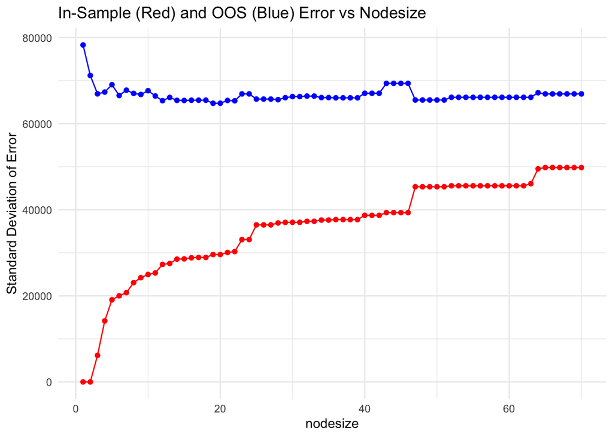

```r
# Plot the errors to visualize the trade-off.
ggplot(data.frame(
  nodesize = 1:max_nodesize_to_try,
  in_sample_errors = in_sample_errors,
  oos_errors = oos_errors
)) +
  geom_point(aes(x = nodesize, y = in_sample_errors), col = "red") +
  geom_line(aes(x = nodesize, y = in_sample_errors), col = "red") +
  geom_point(aes(x = nodesize, y = oos_errors), col = "blue") +
  geom_line(aes(x = nodesize, y = oos_errors), col = "blue") +
  labs(
    title = "In-Sample (Red) and OOS (Blue) Error vs Nodesize",
    x = "nodesize",
    y = "Standard Deviation of Error"
  ) +
  theme_minimal()
```

The blue line (out-of-sample error) shows the sweet spot. We choose the `nodesize` that gives the minimum error on the validation set.

```r
# Find the nodesize that minimizes the out-of-sample error.
best_nodesize = which.min(oos_errors)
cat("Best nodesize based on validation set:", best_nodesize, "\n")
```

```
## Best nodesize based on validation set: 19
```

## Final Regression Tree

Now we train the final regression tree using the `best_nodesize` on the combined training and validation data.

```r
# Combine the training and validation sets.
X_train_select = rbind(X_train, X_select)
y_train_select = c(y_train, y_select)

# Train the final tree model.
tree_mod = YARFCART(X_train_select, y_train_select, nodesize = best_nodesize, calculate_oob_error = FALSE)
```

We can visualize the structure of our trained tree.

```r
# Get tree metrics.
get_tree_num_nodes_leaves_max_depths(tree_mod)
```

```
## $num_nodes
## [1] 73
##
## $num_leaves
## [1] 37
##
## $max_depth
## [1] 15
```

```r
# Generate an illustration of the tree
illustrate_trees(tree_mod, max_depth = 6, open_file = TRUE)
```

## Regression Tree Performance

Let’s evaluate the performance using Root Mean Squared Error (RMSE) and R-squared (R²).

### In-Sample Performance

```r
# Predict on the training data.
y_hat_train_select = predict(tree_mod, X_train_select)

# Calculate in-sample RMSE and R².
rmse_train_select = sqrt(mean((y_train_select - y_hat_train_select)^2))
ss_res_train_select = sum((y_train_select - y_hat_train_select)^2)
ss_tot_train_select = sum((y_train_select - mean(y_train_select))^2)
r2_train_select = 1 - ss_res_train_select / ss_tot_train_select

cat("In-sample RMSE:", rmse_train_select, "\n")
```

```
## In-sample RMSE: 40496.21
```

```r
cat("In-sample R²:", r2_train_select, "\n")
```

```
## In-sample R²: 0.9476025
```

### Out-of-Sample Performance

Now for the true test: performance on the unseen test data.

```r
# Predict on the test data.
y_hat_test = predict(tree_mod, X_test)

# Calculate out-of-sample RMSE and R².
oos_rmse_tree = sqrt(mean((y_test - y_hat_test)^2))
ss_res = sum((y_test - y_hat_test)^2)
ss_tot = sum((y_test - mean(y_test))^2)
oos_r2_tree = 1 - ss_res / ss_tot

cat("Out-of-sample RMSE:", oos_rmse_tree, "\n")
```

```
## Out-of-sample RMSE: 75999.5
```

```r
cat("Out-of-sample R²:", oos_r2_tree, "\n")
```

```
## Out-of-sample R²: 0.838751
```

# Linear Modeling

Next, we’ll fit a linear model. This serves as a strong baseline to compare against our more complex tree-based models.

```r
# Fit a multiple linear regression model.
lm_model = lm(y_train_select ~ ., data = data.frame(X_train_select, y_train_select))
round(coef(lm_model), 3)
```

```
##                   (Intercept)             approx_year_built
##                   -229559.600                        81.343
##               cats_allowedyes      community_district_num25
##                      6103.215                     10671.895
##      community_district_num26      community_district_num27
##                     38698.362                     22379.270
##      community_district_num28      community_district_num29
##                     41405.093                     48388.130
##      community_district_num30   community_district_numother
##                      3084.153                      7701.342
##               coop_condocondo        dining_room_typeformal
##                     34858.835                       606.894
##         dining_room_typeother               dogs_allowedyes
##                     -8046.169                      1208.338
##                  fuel_typegas                 fuel_typenone
##                     31436.391                     68891.911
##                  fuel_typeoil                fuel_typeother
##                     27427.219                     35252.935
##              garage_existsyes            kitchen_typeeat_in
##                      5595.774                     -4936.952
##        kitchen_typeefficiency              kitchen_typenone
##                     -5788.777                     23135.758
##                  num_bedrooms        num_floors_in_building
##                      8758.695                      -284.757
##            num_full_bathrooms            num_half_bathrooms
##                      3832.672                     -6585.686
##               num_total_rooms               parking_charges
##                     -1403.748                       -28.889
##             pct_tax_deductibl                    sq_footage
##                       947.904                        20.922
##                   total_taxes                    walk_score
##                        -7.017                      -466.775
## listing_price_to_nearest_1000                  general_cost
##                       814.867                        19.709
##                 zip_code11005                 zip_code11101
##                     41544.002                     30090.153
##                 zip_code11102                 zip_code11104
##                    101825.447                    -12673.108
##                 zip_code11105                 zip_code11106
##                    162639.142                     42292.091
```

[output cut: 19 more lines]

```
##                     13556.719                     45776.399
##                 zip_code11378                 zip_code11379
##                     38341.438                     57535.151
##                 zip_code11385                 zip_code11414
##                     10275.338                    -39154.210
##                 zip_code11415                 zip_code11417
##                    -10911.307                    -38194.296
##                 zip_code11421                 zip_code11422
##                      9032.360                    -66888.372
##                 zip_code11423                 zip_code11426
##                    -27960.560                      3420.148
##                 zip_code11427                 zip_code11432
##                    -17344.980                     -7173.854
##                 zip_code11435                 zip_codeother
##                     -6659.130                    -82978.397
```

## Linear Model Performance

### In-Sample Performance

```r
# Predict on the training data.
y_hat_lm_train_select = predict(lm_model, X_train_select)

# Calculate in-sample RMSE.
rmse_lm_train_select = sqrt(mean((y_train_select - y_hat_lm_train_select)^2))
cat("In-sample RMSE:", rmse_lm_train_select, "\n")
```

```
## In-sample RMSE: 37285.14
```

```r
# Calculate in-sample R².
ss_res = sum((y_train_select - y_hat_lm_train_select)^2)
ss_tot = sum((y_train_select - mean(y_train_select))^2)
r2_lm_train_select = 1 - ss_res / ss_tot
cat("In-sample R²:", r2_lm_train_select, "\n")
```

```
## In-sample R²: 0.9555826
```

### Out-of-Sample Performance

```r
# Predict on the test data.
oos_y_hat_lm_test = predict(lm_model, X_test)

# Calculate out-of-sample RMSE.
oos_rmse_lm_test = sqrt(mean((y_test - oos_y_hat_lm_test)^2))
cat("Out-of-sample RMSE:", oos_rmse_lm_test, "\n")
```

```
## Out-of-sample RMSE: 73078.77
```

```r
# Calculate out-of-sample R².
ss_res = sum((y_test - oos_y_hat_lm_test)^2)
ss_tot = sum((y_test - mean(y_test))^2)
r2_lm_test = 1 - ss_res / ss_tot
cat("Out-of-sample R²:", r2_lm_test, "\n")
```

```
## Out-of-sample R²: 0.8509068
```

# Random Forest Modeling

Finally, we build a random forest model. Random forests are an ensemble of many decision trees and are known for their high predictive accuracy. We need to tune the `mtry` hyperparameter, which is the number of features considered at each split in a tree.

## Finding the Best `mtry`

We will use the `randomForest` package to tune `mtry`. We’ll loop through all possible values of `mtry`, train a forest, and find the one that gives the lowest RMSE on our validation set.

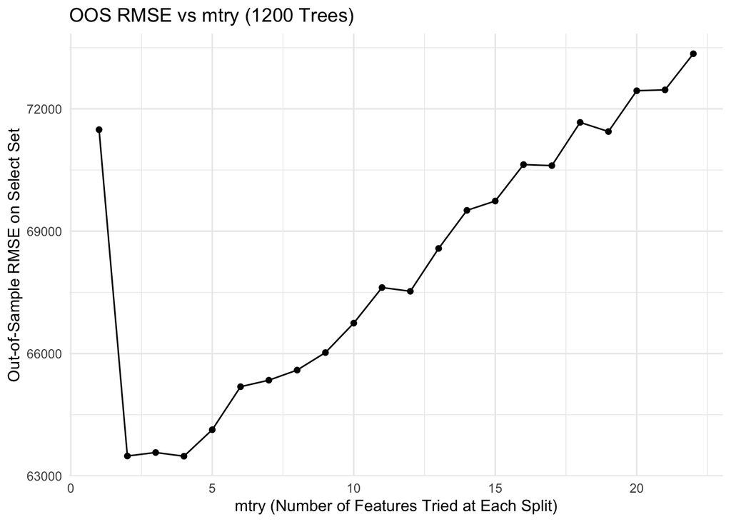

```r
library(randomForest)
# Combine training data for the randomForest function format.
df_train = data.frame(X_train)
df_train$sale_price = y_train

df_select = data.frame(X_select)
df_select$sale_price = y_select

p = ncol(X_train)  # number of predictors
num_trees = 1200
oos_se_by_mtry = numeric(p)

# Loop over mtry from 1 to p.
for (m in 1:p) {
  rf_model = randomForest(sale_price ~ ., data = df_train, ntree = num_trees, mtry = m)
  y_hat_select = predict(rf_model, newdata = df_select)
  oos_se_by_mtry[m] = sqrt(mean((df_select$sale_price - y_hat_select)^2))  # RMSE
}

# Create a data frame for plotting.
df_mtry = data.frame(
  mtry = 1:p,
  oos_rmse = oos_se_by_mtry
)

# Plot OOS RMSE vs mtry.
library(ggplot2)
ggplot(df_mtry, aes(x = mtry, y = oos_rmse)) +
  geom_point() +
  geom_line() +
  labs(
    title = "OOS RMSE vs mtry (1200 Trees)",
    x = "mtry (Number of Features Tried at Each Split)",
    y = "Out-of-Sample RMSE on Select Set"
  ) +
  theme_minimal()
```

```r
# Find the best mtry.
best_mtry = which.min(oos_se_by_mtry)
cat("Best mtry based on OOS RMSE:", best_mtry, "\n")
```

```
## Best mtry based on OOS RMSE: 4
```

## Final Random Forest Model

With the optimal `mtry` found, we train our final random forest model using the `YARF` package, which is optimized for performance. We’ll train it on the combined training and validation data.

```r
# Set a seed for reproducibility.
seed = 42
num_trees = 1000

# Train the final random forest model with the best mtry.
mod_rf = YARF(X_train_select, y_train_select, num_trees = num_trees, seed = seed, mtry = best_mtry, nodesize = 1,    calculate_oob_error = FALSE, verbose = FALSE)
mod_rf
```

```
## YARF v1.1 for regression
## Missing data feature ON.
## 1000 trees, training data n = 428 and p = 82
## Model construction completed within 0.02 minutes.
## Run the 'YARF_update_with_oob_results' function to get out of sample
## performance estimates using the out of bag predictions.
```

## Random Forest Performance

### In-Sample Performance

```r
# Predict on the training data.
y_hat_rf_train_select = predict(mod_rf, X_train_select)

# Calculate in-sample RMSE.
rmse_rf_train_select = sqrt(mean((y_train_select - y_hat_rf_train_select)^2))

# Calculate in-sample R².
ss_res_train_select = sum((y_train_select - y_hat_rf_train_select)^2)
ss_tot_train_select = sum((y_train_select - mean(y_train_select))^2)
r2_rf_train_select = 1 - ss_res_train_select / ss_tot_train_select

cat("In-sample RMSE:", rmse_rf_train_select, "\n")
```

```
## In-sample RMSE: 59146.42
```

```r
cat("In-sample R²:", r2_rf_train_select, "\n")
```

```
## In-sample R²: 0.8882265
```

### Out-of-Sample Performance

This is the most important evaluation, as it shows how the model generalizes to new data.

```r
# Predict on the test data.
y_hat_rf_test = predict(mod_rf, X_test)

# Calculate out-of-sample RMSE.
rmse_rf_test = sqrt(mean((y_test - y_hat_rf_test)^2))

# Calculate out-of-sample R².
ss_res_test = sum((y_test - y_hat_rf_test)^2)
ss_tot_test = sum((y_test - mean(y_test))^2)
r2_rf_test = 1 - ss_res_test / ss_tot_test

cat("Out-of-sample RMSE:", rmse_rf_test, "\n")
```

```
## Out-of-sample RMSE: 99791.76
```

```r
cat("Out-of-sample R²:", r2_rf_test, "\n")
```

```
## Out-of-sample R²: 0.7219872
```

# Shipping Final Model

```r
# Combine all labeled data.
X_final = rbind(X_train, X_select, X_test)
y_final = c(y_train, y_select, y_test)

# Fit the final YARF model on all available data.
mod_rf_final = YARF(X_final, y_final,
                    num_trees = num_trees,
                    seed = seed,
                    mtry = best_mtry,
                    nodesize = 1,   calculate_oob_error = FALSE, verbose = FALSE)
mod_rf_final
```

```
## YARF v1.1 for regression
## Missing data feature ON.
## 1000 trees, training data n = 528 and p = 82
## Model construction completed within 0.02 minutes.
## Run the 'YARF_update_with_oob_results' function to get out of sample
## performance estimates using the out of bag predictions.
```

This `mod_rf_final` object is our finished product, ready to make predictions on new data.